# Test Report

## Monthly

#### Report reference: FH001

#### Report creation date-time: 21/10/2022, 00:47 AM

#### Data cutoff date-time: 30/09/2022, 23:59 PM

Information & Insight

**Notes:**  
A key explaining how to read the icons for Variation, Assurance, and Data Quality is at the bottom of this document.

Vari -ation

Assur -ance

Data Quality

**Updated to 30-Jun-2022 Target - Set by - Actual 200 Neutral**

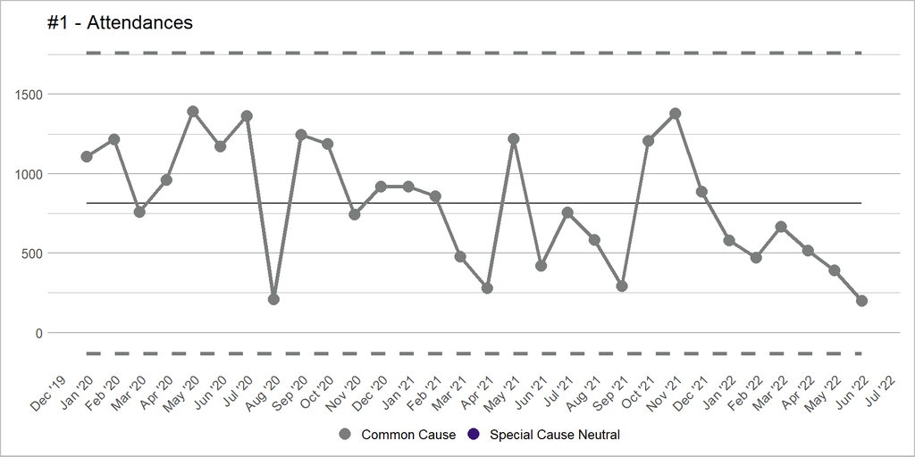

Accountable Person: -

Data owner: Central Information Team

**Updated to 02-Aug-2020 Target - Set by - Actual 222 Neutral**

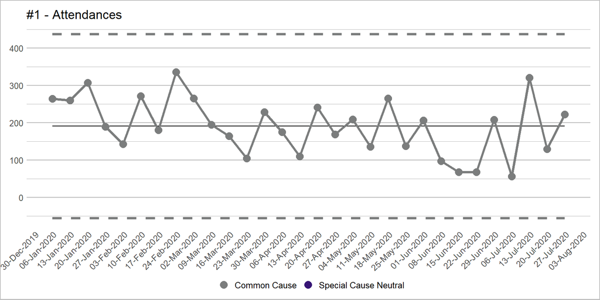

Accountable Person: -

Data owner: Central Information Team

**Updated to 02-Aug-2020 Target ≤ 0.7 Set by NHSE Actual 0.73**

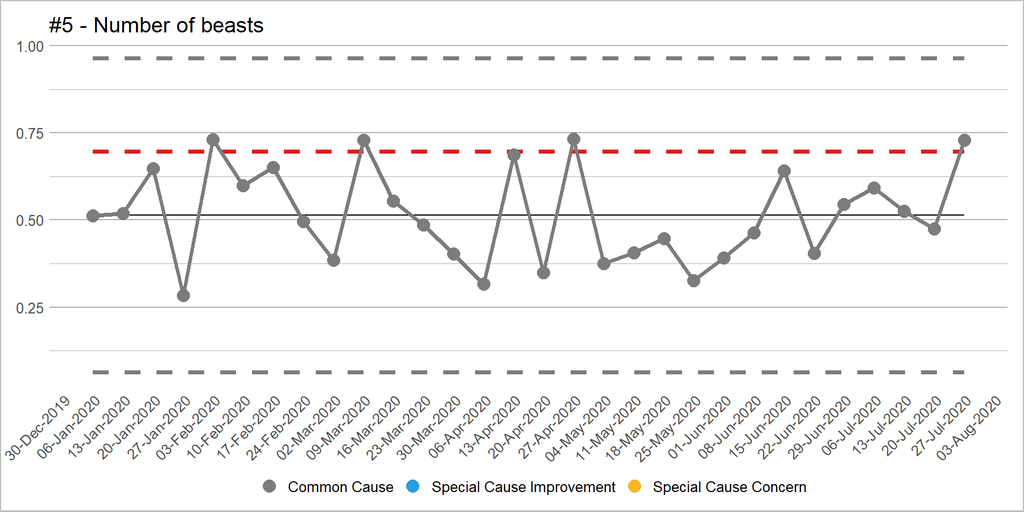

Accountable Person: Hannah Harvey (Service GM)

Data owner: Divisional Information Team

**Updated to 02-Aug-2020 Target ≥ 70.8% Set by Trust Actual 49.2%**

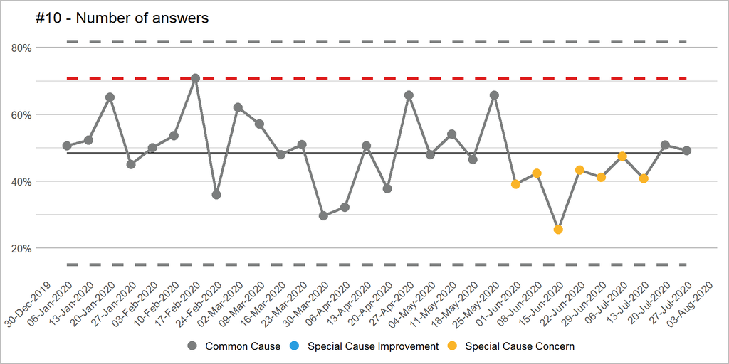

Accountable Person: Hannah Harvey (Service GM)

Data owner: Divisional Information Team

**Updated to 30-Jun-2022 Target - Set by - Actual 47% No target**

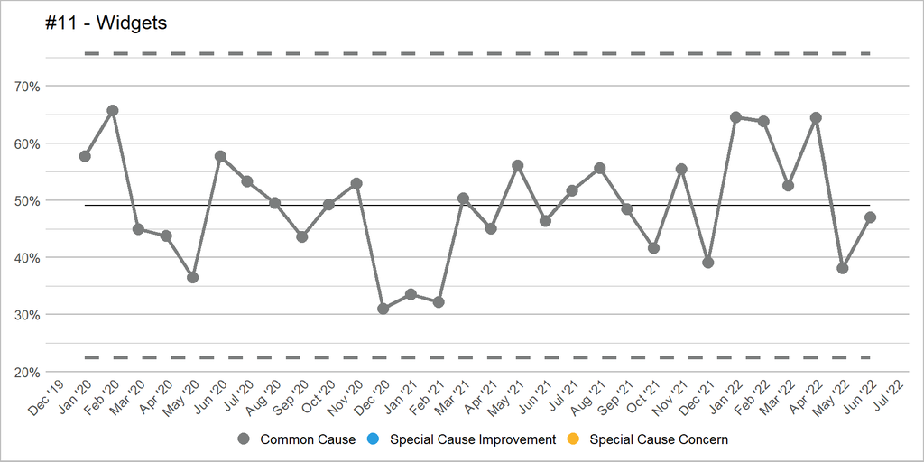

Accountable Person: Tony Smith (Divisional Governance)

Data owner: Divisional Information Team

**Updated to 02-Aug-2020 Target ≥ 90% Set by Division Actual 47%**

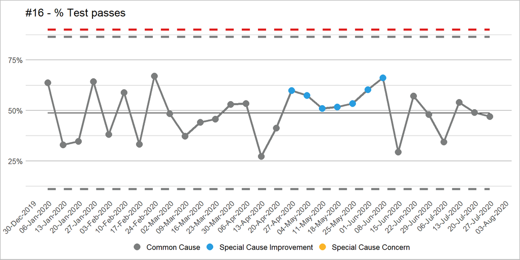

Accountable Person: Sally Fenwick (Divisional HR)

Data owner: Corporate HR

**Updated to 02-Aug-2020 Target ≥ 0.49 Set by Trust Actual 0.46**

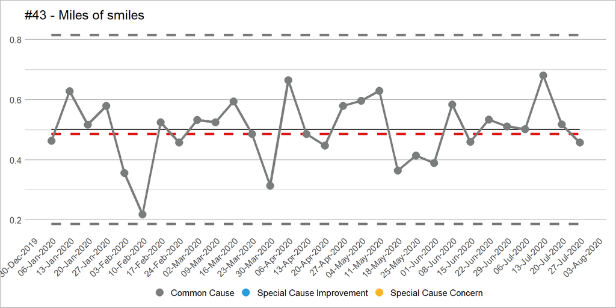

Accountable Person: Hannah Harvey (Service GM)

Data owner: Central Information Team

**SPC Variation Icons**

Used to summarise the type of variation seen in the most recent data point of a given measure.

Icons

Variation Type

The most recent data point exhibits special cause variation (in a concerning direction). H is high, L is Low.

The most recent data point exhibits special cause variation (in an improving direction). H is high, L is Low.

The most recent data point exhibits special cause variation, but neither direction represents concern or improvement (ie. the measure is neutral). H is high, L is low.

The most recent data point exhibits common cause variation (ie. naturally-occurring variation, that is not statistically significant).

**SPC Assurance Icons**

Used to summarise whether a measure is assured to meet a target.

| Icons | Assurance Type |
| --- | --- |
|  | The process is assured, and is likely to consistently pass the target set. |
|  | The process is not assured, and will pass and fail the target based on variation in the process. |
|  | The process is not assured, and is likely to consistently fail to meet the target set. |

Report reference: FH001  
Report author: Tom Smith (FH Insight Manager) thomas.smith5@nuh.nhs.uk

END